# Borlange

Jon Frank

2023-03-23

### Borlänge kommun

Borlänge kommuns befolkningsantal, Dalarnas näst största, har ökat stadigt under en lång period, från ca 43000 invånare i slutet av 60-talet till drygt 52000 år 2022. Under 2000-talet har den ökning utgjorts av personer födda utanför Sverige, medan de som är inrikes födda har minskat något. Sett till invånarnas ålder är Borlänge Dalarnas yngsta kommun, med en medelålder på drygt 41 år. Arbetslösheten i Borlänge, närmare 7 procent, är däremot Dalarnas tredje högsta, medan andelen högutbildade är ungefär som länets genomsnitt. Att arbetslösheten är hög kan delvis förklaras med att Borlänge har Dalarnas näst största andel utrikes födda invåndare, drygt 18 procent. Utikes födda har generellt en klart högre arbetslöshet än inrikes födda. Borlänge är samtidigt den kommun i Dalarna som har klart högst inpendling, då nästan 40 procent av de som förvärvsarbetar i kommunen inte bor där.

[figure not shown]

Figur 10

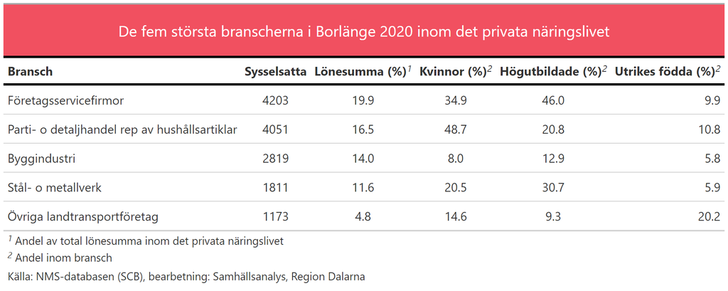

Figur 9

Borlänge är ungefär genomsnittligt i Dalarna när det kommer till antal företag (per 1000 invånare), men samtidigt startas relativt få företag i kommunen. Borlänge är dessutom den kommun där näst minst antal personer per 1000 invånare räknas som företagssamma. Positivt ur sårbarhetssynvinkel är dock att Borlänge är näst bäst i Dalarna vad gäller såväl branschbredd som antal företag som utgör 50 procent av lönesumman, något som delvis kan tillskrivas kommunens storlek (Dalarnas största kommun Falun är etta i båda kategorierna) Noterbart är dock att Borlänge har ett par stora företag inom det privata näringslivet, exempelvis SSAB, vilket är en potentiell riskfaktor.